# Cyclistic Case Study Capstone Project

Dan Lee

2023-05-22

**Google Data Analytics Certificate Capstone Project**

*Optional Case study project for the google data analytics certificate offered on coursera*

**Company background**

In 2016, Cyclistic launched a successful bike-share offering. Since then, the program has grown to a fleet of 5,824 bicycles that are geotracked and locked into a network of 692 stations across Chicago. The bikes can be unlocked from one station and returned to any other station in the system anytime.

Until now, Cyclistic’s marketing strategy relied on building general awareness and appealing to broad consumer segments. One approach that helped make these things possible was the flexibility of its pricing plans: single-ride passes, full-day passes, and annual memberships. Customers who purchase single-ride or full-day passes are referred to as casual riders. Customers who purchase annual memberships are Cyclistic members.

Cyclistic’s finance analysts have concluded that annual members are much more profitable than casual riders. Although the pricing flexibility helps Cyclistic attract more customers, Cyclistic believes maximizing the number of annual memberships, by converting single-ride and full-day users to annual members will drive revenue growth.

**Business question**

How do annual members and casual riders use Cyclistic bikes differently?

**Setting up my environment**

```r
setwd("E:/googledatanalytics/12monthbikedataset")
```

**Libraries used to process data**

```r
library(tidyverse)
library(lubridate)
library(ggplot2)
```

Cyclistic bike trip data set is available at the following link: https://divvy-tripdata.s3.amazonaws.com/index.html

This case study was done using 12 months of data from the Cyclistic bike trip data set.

**Upload the data**

```r
data_2022_01 <- read.csv("202201-divvy-tripdata.csv")
data_2022_02 <- read.csv("202202-divvy-tripdata.csv")
data_2022_03 <- read.csv("202203-divvy-tripdata.csv")
data_2022_04 <- read.csv("202204-divvy-tripdata.csv")
data_2022_05 <- read.csv("202205-divvy-tripdata.csv")
data_2022_06 <- read.csv("202206-divvy-tripdata.csv")
data_2022_07 <- read.csv("202207-divvy-tripdata.csv")
data_2022_08 <- read.csv("202208-divvy-tripdata.csv")
data_2022_09 <- read.csv("202209-divvy-tripdata.csv")
data_2022_10 <- read.csv("202210-divvy-tripdata.csv")
data_2022_11 <- read.csv("202211-divvy-tripdata.csv")
data_2022_12 <- read.csv("202212-divvy-tripdata.csv")
```

**Combine all data into single dataframe then drop data tables**

```r
data_2022_12_months <- rbind(data_2022_01, data_2022_02, data_2022_03, data_2022_04, data_2022_05, data_2022_06, data_2022_07, data_2022_08, data_2022_09, data_2022_10, data_2022_11, data_2022_12)
remove(data_2022_01, data_2022_02, data_2022_03, data_2022_04, data_2022_05, data_2022_06, data_2022_07, data_2022_08, data_2022_09, data_2022_10, data_2022_11, data_2022_12)
```

**Copy of new dataframe**

```r
data_2022_12_months_2 <- data_2022_12_months
```

**Reformatting data types**

adding ride length, day of week, date, month, day, year and season. ordering week, month, and season.

```r
#adding ride length in minutes
data_2022_12_months_2$ride_length_mins <- difftime(data_2022_12_months_2$ended_at
                                              , data_2022_12_months$started_at
                                              , units = "mins")
#create numeric columns for the day of week, date, month, day, year
data_2022_12_months_2$day_of_week <- wday(data_2022_12_months_2$started_at)
data_2022_12_months_2$date <- as.Date(data_2022_12_months_2$started_at)
data_2022_12_months_2$day_of_week <- format(as.Date(data_2022_12_months_2$date), "%A")
data_2022_12_months_2$month <- format(as.Date(data_2022_12_months_2$date), "%m")
data_2022_12_months_2$day <- format(as.Date(data_2022_12_months_2$date), "%d")
data_2022_12_months_2$year <- format(as.Date(data_2022_12_months_2$date), "%Y")
#create column for seasons classification
data_2022_12_months_2 <- data_2022_12_months_2 %>% mutate(season =
                                                            case_when(month == "03" ~ "Spring",month == "04" ~ "Spring",month == "05" ~ "Spring",month == "06" ~ "Summer",month == "07" ~ "Summer",month == "08" ~ "Summer",month == "09" ~ "Fall",month == "10" ~ "Fall",month == "11" ~ "Fall",month == "12" ~ "Winter",month == "01" ~ "Winter",month == "02" ~ "Winter")
)
#arranges day of week in order
data_2022_12_months_2$day_of_week <- ordered(data_2022_12_months_2$day_of_week, levels=c("Monday","Tuesday","Wednesday","Thursday","Friday","Saturday","Sunday"))
#arranges season in order
data_2022_12_months_2$season <- ordered(data_2022_12_months_2$season, levels=c("Spring", "Summer", "Fall", "Winter"))
#arranges months in order
  data_2022_12_months_2$month <- ordered(data_2022_12_months_2$month, levels=c("01", "02", "03", "04", "05", "06", "07","08","09","10","11","12"))
#converts values from scientific notation <- run this for y axis proper formatting
options(scipen = 999)
```

**Cleaning data**

removing duplicates, nulls, ride length <= 0 and unnecessary columns. rename and convert ride_length_mins to numeric values.

```r
data_2022_12_months_2 <- distinct(data_2022_12_months_2)
data_2022_12_months_2 <- na.omit(data_2022_12_months_2)
data_2022_12_months_2 <- data_2022_12_months_2[!(data_2022_12_months_2$ride_length_mins <=0),]
data_2022_12_months_2 <- data_2022_12_months_2[ , ! names(data_2022_12_months_2) %in% c("ride_id", "start_station_id", "end_station_id", "start_lat", "start_lng", "end_lat", "end_lng")]
data_2022_12_months_2 <- data_2022_12_months_2 %>% rename(member_type = member_casual)
data_2022_12_months_2$ride_length_mins <- as.numeric(as.character(data_2022_12_months_2$ride_length_mins))
```

**Viewing the dataframe**

```r
colnames(data_2022_12_months_2)
```

```
##  [1] "rideable_type"      "started_at"         "ended_at"
##  [4] "start_station_name" "end_station_name"   "member_type"
##  [7] "ride_length_mins"   "day_of_week"        "date"
## [10] "month"              "day"                "year"
## [13] "season"
```

```r
dim(data_2022_12_months_2)
```

```
## [1] 5661328      13
```

```r
head(data_2022_12_months_2,5)
```

```
##   rideable_type          started_at            ended_at
## 1 electric_bike 2022-01-13 11:59:47 2022-01-13 12:02:44
## 2 electric_bike 2022-01-10 08:41:56 2022-01-10 08:46:17
## 3  classic_bike 2022-01-25 04:53:40 2022-01-25 04:58:01
## 4  classic_bike 2022-01-04 00:18:04 2022-01-04 00:33:00
## 5  classic_bike 2022-01-20 01:31:10 2022-01-20 01:37:12
##              start_station_name              end_station_name member_type
## 1      Glenwood Ave & Touhy Ave          Clark St & Touhy Ave      casual
## 2      Glenwood Ave & Touhy Ave          Clark St & Touhy Ave      casual
## 3 Sheffield Ave & Fullerton Ave Greenview Ave & Fullerton Ave      member
## 4      Clark St & Bryn Mawr Ave     Paulina St & Montrose Ave      casual
## 5   Michigan Ave & Jackson Blvd        State St & Randolph St      member
##   ride_length_mins day_of_week       date month day year season
## 1         2.950000    Thursday 2022-01-13    01  13 2022 Winter
## 2         4.350000      Monday 2022-01-10    01  10 2022 Winter
## 3         4.350000     Tuesday 2022-01-25    01  25 2022 Winter
## 4        14.933333     Tuesday 2022-01-04    01  04 2022 Winter
## 5         6.033333    Thursday 2022-01-20    01  20 2022 Winter
```

**Descriptive Analysis**

The analysis finds the mean, median, maximum and minimum of the ride_length_mins column. These statistics are then compared across both rider types.

```r
aggregate(data_2022_12_months_2$ride_length_mins ~ data_2022_12_months_2$member_type, FUN = mean)
```

```
##   data_2022_12_months_2$member_type data_2022_12_months_2$ride_length_mins
## 1                            casual                               21.99007
## 2                            member                               12.41319
```

```r
aggregate(data_2022_12_months_2$ride_length_mins ~ data_2022_12_months_2$member_type, FUN = median)
```

```
##   data_2022_12_months_2$member_type data_2022_12_months_2$ride_length_mins
## 1                            casual                              12.966667
## 2                            member                               8.833333
```

```r
aggregate(data_2022_12_months_2$ride_length_mins ~ data_2022_12_months_2$member_type, FUN = min)
```

```
##   data_2022_12_months_2$member_type data_2022_12_months_2$ride_length_mins
## 1                            casual                             0.01666667
## 2                            member                             0.01666667
```

```r
aggregate(data_2022_12_months_2$ride_length_mins ~ data_2022_12_months_2$member_type, FUN = max)
```

```
##   data_2022_12_months_2$member_type data_2022_12_months_2$ride_length_mins
## 1                            casual                              34294.067
## 2                            member                               1499.933
```

This analysis shows number of members and bikes by type.

```r
#count member types
data_2022_12_months_2 %>% count(member_type)
```

```
##   member_type       n
## 1      casual 2316600
## 2      member 3344728
```

```r
#count bike types
data_2022_12_months_2 %>% group_by(rideable_type) %>% count(rideable_type)
```

```
## # A tibble: 3 × 2
## # Groups:   rideable_type [3]
##   rideable_type       n
##   <chr>           <int>
## 1 classic_bike  2597846
## 2 docked_bike    174852
## 3 electric_bike 2888630
```

```r
#total rides by bike type by member type
data_2022_12_months_2 %>%
  group_by(member_type, rideable_type) %>%
  count(rideable_type)
```

```
## # A tibble: 5 × 3
## # Groups:   member_type, rideable_type [5]
##   member_type rideable_type       n
##   <chr>       <chr>           <int>
## 1 casual      classic_bike   888853
## 2 casual      docked_bike    174852
## 3 casual      electric_bike 1252895
## 4 member      classic_bike  1708993
## 5 member      electric_bike 1635735
```

**The following bar plot shows member vs casual number of rides by bicycle types**

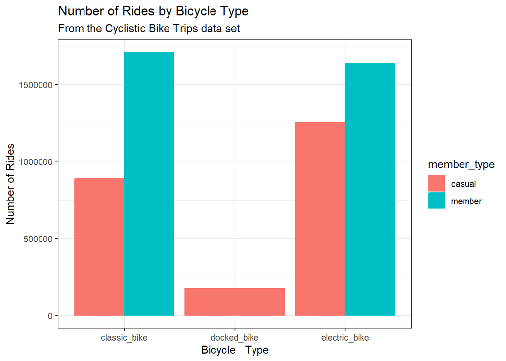

```r
#plot 1 bicycle type by number of rides
  data_2022_12_months_2 %>%
    group_by(rideable_type, member_type) %>%
    summarise(count_trips = n()) %>%
    ggplot(aes(x=rideable_type, y=count_trips, fill=member_type, color=member_type)) +
    geom_bar(stat='identity', position='dodge') +
    theme_bw()+
    labs(title="Number of Rides by Bicycle Type", subtitle = "From the Cyclistic Bike Trips data set", x="Bicycle   Type", y="Number of Rides")
```

Casual riders rode classic bikes 888,853, docked bikes 174,852, and electric bikes 1,252,895.

Annual member riders rode classic bikes 1,708,993, and electric bikes 1,635,735 with this information we can conclude that docked bicycle might not be necessary as they have the least amount of usages out of all the bikes and only casual riders seem to use them.

**The following bar plot shows member vs casual number of rides by day of week**

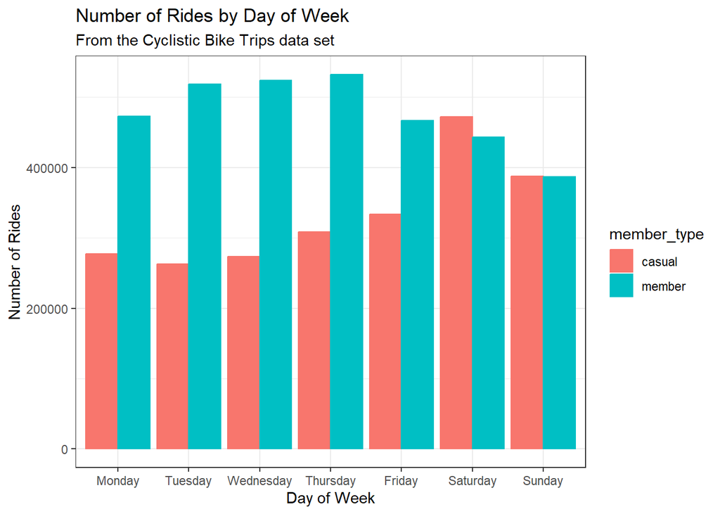

```r
#plot 2 number of rides by day of week
  data_2022_12_months_2 %>%
    group_by(member_type, day_of_week) %>%
    summarise(count_trips = n()) %>%
    ggplot(aes(x=day_of_week, y=count_trips, fill=member_type, color=member_type)) +
    geom_bar(stat='identity', position = 'dodge') +
    theme_bw()+
    labs(title ="Number of Rides by Day of Week", subtitle = "From the Cyclistic Bike Trips data set", x = "Day of Week", y = "Number of Rides")
```

This graph shows that the number of rides differ from member type as casual riders tend to ride more during the weekend and that members ride more consistently throughout the whole week.

**The following bar plot show member vs casual number of rides by month**

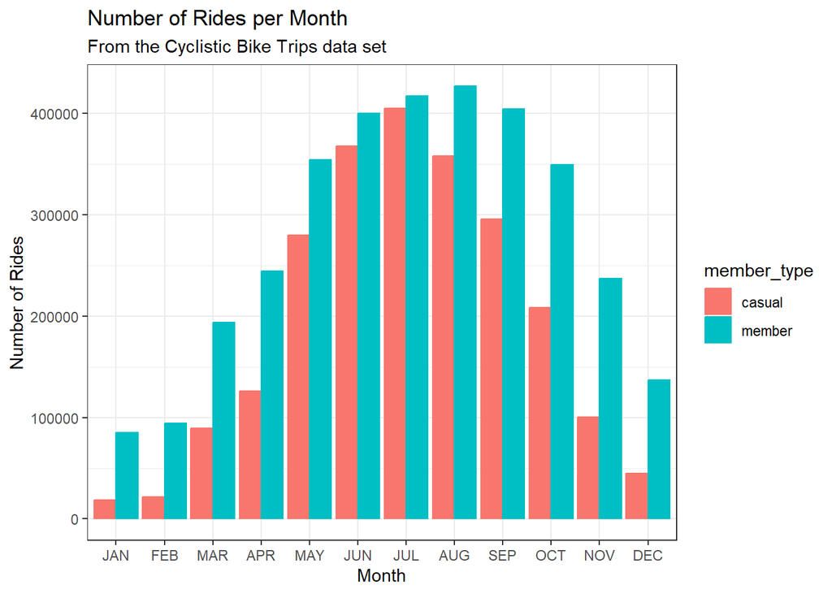

```r
  data_2022_12_months_2 %>%
    group_by(member_type, month) %>%
    summarise(count_trips = n()) %>%
    ggplot(aes(x=month, y=count_trips, fill=member_type, color=member_type)) +
    geom_bar(stat='identity', position = 'dodge') +
    scale_x_discrete(labels=c('JAN', 'FEB', 'MAR', 'APR', 'MAY', 'JUN', 'JUL', 'AUG', 'SEP', 'OCT', 'NOV', 'DEC')) +
    theme_bw() +
    labs(title ="Number of Rides per Month", subtitle = "From the Cyclistic Bike Trips data set", x = "Month", y = "Number of Rides")
```

Filtering the data by seasons show that the most busiest ride usages are during the summer and drop off towards the winter seasons which could indicate that most riders prefer to ride bikes when the weather is warmer rather than colder.

```r
#total rides by season and member type
data_2022_12_months_2 %>%
    group_by(season, member_type) %>%
    count(season)
```

```
## # A tibble: 8 × 3
## # Groups:   season, member_type [8]
##   season member_type       n
##   <ord>  <chr>         <int>
## 1 Spring casual       495475
## 2 Spring member       793272
## 3 Summer casual      1131336
## 4 Summer member      1244228
## 5 Fall   casual       605182
## 6 Fall   member       990965
## 7 Winter casual        84607
## 8 Winter member       316263
```

```r
#total rides by season
  data_2022_12_months_2 %>%
    group_by(season) %>%
    count(season)
```

```
## # A tibble: 4 × 2
## # Groups:   season [4]
##   season       n
##   <ord>    <int>
## 1 Spring 1288747
## 2 Summer 2375564
## 3 Fall   1596147
## 4 Winter  400870
```

**The following bar plot show member vs casual number of rides by season**

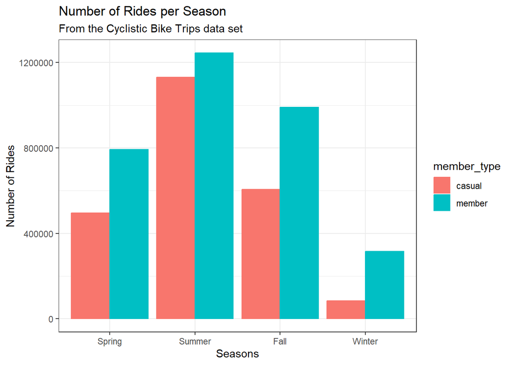

```r
  data_2022_12_months_2 %>%
    group_by(member_type, season) %>%
    summarise(count_trips = n()) %>%
    ggplot(aes(x=season, y=count_trips, fill=member_type, color=member_type)) +
    geom_bar(stat='identity', position='dodge') +
    theme_bw() +
    labs(title ="Number of Rides per Season", subtitle = "From the Cyclistic Bike Trips data set", x = "Seasons", y = "Number of Rides")
```

**This data shows the top 5 stations for casual riders**

```r
  data_2022_12_months_2 %>%
    group_by(member_type, start_station_name) %>%
    summarise(number_of_ride = n()) %>%
    filter(start_station_name != "", "casual"== member_type) %>%
    arrange(-number_of_ride) %>%
    head(n=5) %>%
    select(-member_type)
```

```
## # A tibble: 5 × 3
## # Groups:   member_type [1]
##   member_type start_station_name                 number_of_ride
##   <chr>       <chr>                                       <int>
## 1 casual      Streeter Dr & Grand Ave                     57844
## 2 casual      DuSable Lake Shore Dr & Monroe St           31747
## 3 casual      Millennium Park                             25400
## 4 casual      Michigan Ave & Oak St                       25225
## 5 casual      DuSable Lake Shore Dr & North Blvd          23583
```

**Recommendations**

My top 3 recommendations are:

1. Increase marketing during Spring and Summer to bring in more riders during peak bike usages.
2. Reach out to nearby businesses to promote bicycle commuting among their staff through targeted outreach.
3. Offer casual users a promotional upgrade to full membership status. These promotions should target the most popular starting stations within casual users.

**Further visualizations and analysis in tableau**

Link: https://public.tableau.com/app/profile/dan.lee3772/viz/CyclisticBike-ShareDashboard_16853931936210/Dashboard1_1